# Paired Motif Analysis Report

Tristan Sones-Dykes

31/07/23

### Summary

The purpose of this document is to use paired motif analysis to try to find ways of identifying secondary binding motifs in species other than Cerevisiae, this is because one (CNYTCNYT) is bonded chemically to the Ssd-1 protein, whereas the second (CCAACT) is only a physical fit for the protein surface and chemically binds to itself. This explains why the second motif is not required for Ssd-1 function, however, it is still  
important for optimal function.

## Cerevisiae baseline analysis

This begins by generating possible secondary motifs using an input IUPAC code and then finds pairs using the primary motif and a window. These are then plotted as a grid of histograms and enriched genes from CRAC experimental data are highlighted as well as those with signal peptides or other possible heuristics for Ssd-1 binding.

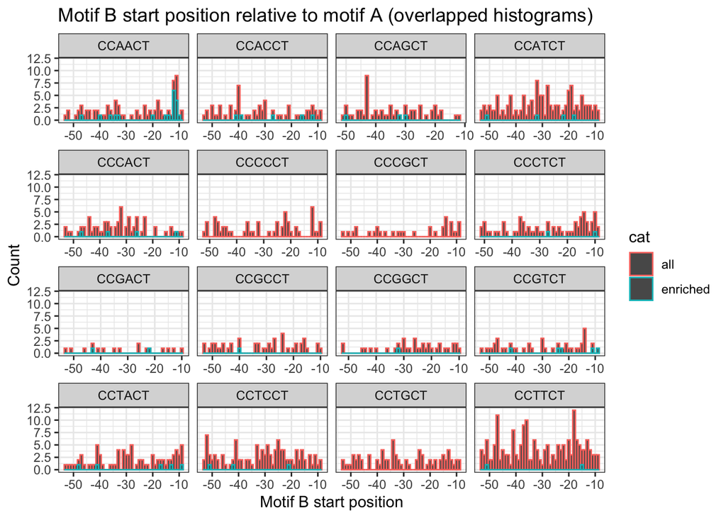

This shows the secondary motif found in the paper using MEME analysis, lets add in other heuristics to see if there are more generalisable rules for finding secondary motif binding sites.

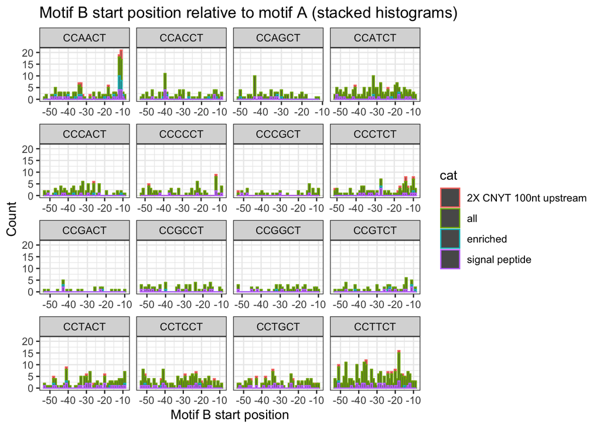

These histograms are stacked because there are more than two categories, so lower ones are hidden by higher ones. This shows that there does seem to be a little bit of correlation with signal peptide detection and the CRAC enriched positions.

## Other Species

For this example we will use Candida Albicans, and use signal peptide detection as the heuristic for Ssd-1 binding.

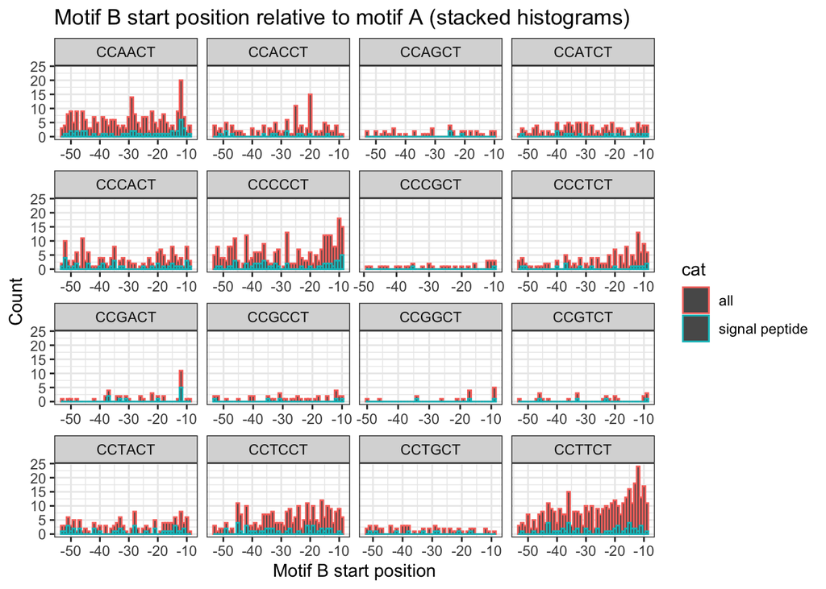